# Tvyal Newsletter

Aghasi Tavadyan

2024-01-26

*English summary below.*

Հարգելի գործընկեր,

Հուսով եմ լավ եք: Ներկայացնում եմ այս շաբաթվա վերլուծությունները և աշխատանքները.

1. Ամուր ընտանիք. հարուստ ընտանիք
2. ԶԼՄ հաղորդագրություններ
3. English summary

## 1. Ամուր ընտանիք. հարուստ ընտանիք

### Հայաստանի ընտանիքների ուսումնասիրություն

> Ոչ լիարժեք ընտանիք է համարվում մեկ ծնողից և երեխայից բաղկացած ընտանիքը:

> Ոչ լիարժեք ընտանիքները բնութագրվում են հետևյալ հատկանիշներով՝
> - որբացած,
> - ծնողազուրկ,
> - ամուսնալուծված։

Դիտարկենք տնային տնտեսությունների եկամուտները ըստ դեցիլային խմբարի և այդ խմբերում սեռատարիքային կազմի։

123 հազար դրամը չգերազանցող ամսական եկամուտ ունեցող ընտանիքները գտնվում են 1-2 դեցիլային խմբերում։ Այս խմբին բնորոշ է տարեցների մեծ մասնաբաժինը, որոնց ընտանիքների ավելի քան 35 տոկոսը բաղկացած է 63 և բարձր տարիքի թոշակառուներից: Այս խմբի ընտանիքների միջին մեծությունը 2 մարդ է։ Այս ընտանիքները հիմնականում լիարժեք չեն, այս խմբում միայն մեկ երրորդն է որ ամուսին ունի: Երեխաների ամենացածր մասնաբաժինը նկատվում է այս խմբում, աշխատունակ տարիքի անձանց ավելի ցածր կշռի հետ մեկտեղ:

**Գծապատկեր 1.** Տնային տնտեսությունների և տարիքային խմբարի բաշխվածությունը

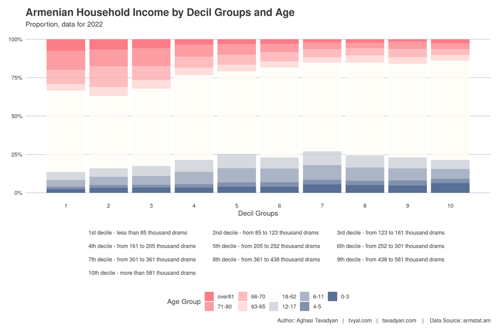

```
Դեցիլային խումբերը տվյալների բազան բաժանում են տասը հավասար մասերի,
որոնցից յուրաքանչյուրը ներկայացնում է ընդհանուր դիտարկումների 10%-ը՝
հավասար համամասնությամբ: Առաջին դեցիլը ներկայացնում է տվյալների
առաջին 10%-ը, երկրորդը ներկայացնում է երկրորդ 10%-ը և այլն, 10-րդ դեցիլը,
ներկայացնում է տվյալների ամենաբարձր 10%-ը:
```

Ինչպես երևում է գծապատկերում ինչքան տնային տնտեսությունը ավելի քիչ է ստանում եկամուտ, այնքան ավելի մեծ է հավանականությունը որ այդ տնային տնտեսությունում տարեցների քանակությունը ավելի մեծ կլինի։ Այսպես 123 հազար դրամից ցածր եկամուտ ստացող տնային տնտեսություններում 1/3-ը 63 և ավել տարիք ունեցող քաղաքացիներ են։ Այսպես այս խմբի վրա ավելի շատ են ընկնում առողջապահական ծախսերը:

Որքան մեծ է տնային տնտեսության գլխի տարիքը և որքան մեծ է տնային տնտեսության գլխի կին լինելու հավանականությունը, այնքան մեծ է ընտանիքի անապահով խավի մեջ հայտնվելու հավանականությունը: Անապահով տնային տնտեսությունները հիմնականում բաղկացած են տարեց կանանցից, ովքեր չունեն հարազատներ, որոնց մոտ 40 տոկոսն ունի հիմնական կրթություն:

Հարուստ խավն առանձնանում է ավելի մեծ ընտանիքներով, ինչի մասին է վկայում 10-րդ դեցիլային խմբում միջինը 5 հոգանոց ընտանիքների չափը։ Ապահովված տնային տնտեսություններն ունեն նաև աշխատողների մեծ թվով անդամներ, որոնցից երեքից ավելի անդամներ գտնվում են աշխատանքային տարիքում: Ավելին՝ ապահով ընտանիքների գլուխների ավելի քան 77 տոկոսն ունի ամուսին։ Այսպիսով, ամբողջական ընտանիքի առկայությունը հիմնականում բնութագրում է ապահովված ընտանիք: Կրթության մակարդակն ամենաբարձրն է 10-րդ դեցիլում, որի 56,3 տոկոսն ունի հիմնական կրթություն:

Միջին խավը հասարակության հիմքն է։ Այս խավն ունի ամենաշատ երեխաների թիվը։ Այս ընտանիքների անդամների մոտավորապես 25 տոկոսը երեխաներ են՝ ի տարբերություն հարուստ խավի, որը համեմատաբար ավելի քիչ երեխաներ ունի։ Ամենաապահով 10-րդ դեցիլային խմբում երեխաների տոկոսը կազմում է 21 տոկոս։

Ամբողջական ընտանիքի առկայությունը էականորեն ազդում է ապահով և միջին խավի ձևավորման վրա, մինչդեռ ցածր խավին առավելապես բնորոշ է միայնությունը։

**Աղյուսակ 1.** ՀՀ տնային տնտեսությունների ժողովրդագրական վերլուծություն

Armenia's Household Demographics

Summary of demographic and income information in 2022

| Household Decile | Average Monthly Income (in thousand AMD) | Demographic Information Working-Age Population (%) | Demographic Information Senior Population (over 63, %) | Demographic Information Child Population (0-17, %) | Household Composition (Average) Household Size | Household Composition (Average) Working-Age | Household Composition (Average) Children | Head of Household (HH) Details Average Age of HH | Head of Household (HH) Details Proportion of Female in HH (%) | Head of Household (HH) Details HH with Basic Education (%) | Head of Household (HH) Details Married HH (%) |
| --- | --- | --- | --- | --- | --- | --- | --- | --- | --- | --- | --- |
| 1 | 65.9 | 52.9% | 33.6% | 13.5% | 1.86 | 0.98 | 0.25 | 65 | 68.6% | 40.6% | 23.8% |
| 2 | 105.0 | 46.9% | 37.5% | 15.6% | 2.24 | 1.05 | 0.35 | 66 | 53.1% | 40.5% | 39.8% |
| 3 | 143.1 | 50.5% | 31.0% | 18.5% | 2.72 | 1.37 | 0.50 | 64 | 43.4% | 40.2% | 52.4% |
| 4 | 186.0 | 55.2% | 23.2% | 21.6% | 3.17 | 1.75 | 0.68 | 62 | 37.2% | 42.4% | 57.4% |
| 5 | 231.3 | 54.4% | 20.2% | 25.4% | 3.62 | 1.97 | 0.92 | 61 | 35.0% | 43.1% | 60.3% |
| 6 | 277.4 | 59.0% | 18.2% | 22.8% | 3.78 | 2.23 | 0.86 | 59 | 25.8% | 47.5% | 70.8% |
| 7 | 336.5 | 58.0% | 15.3% | 26.7% | 4.16 | 2.42 | 1.11 | 58 | 26.5% | 46.2% | 68.8% |
| 8 | 409.8 | 59.9% | 15.2% | 24.9% | 4.47 | 2.68 | 1.11 | 59 | 25.2% | 47.8% | 71.3% |
| 9 | 517.6 | 61.2% | 15.8% | 23.0% | 4.81 | 2.95 | 1.10 | 60 | 18.7% | 49.2% | 77.3% |
| 10 | 722.6 | 65.0% | 13.9% | 21.2% | 5.00 | 3.25 | 1.06 | 59 | 18.3% | 56.3% | 77.5% |

Author: Aghasi Tavadyan | tvyal.com | tavadyan.com | Data Source: armstat.am

> Նշենք որ այս վերլուծությունը տնտային տնտեսությունների վերլուծության 2-րդ մասին է։

> Առաջին վերլուծությունը կարդացեք այստեղ․

> [🏠💰 📉 Տնային տնտեսությունները աղքատացել են](https://www.tvyal.com/newsletter/2024/2024_01_07):

Ինչպես երևում է մինչև 161 հազար դրամ ընդհանուր եկամուտ ստացող առաջին, երկրորդ և երրորդ դեցիլային խմբերի հիմնական դրամական եկամուտը գոյանում է կնսաթոշակից։*

Տնային տնտեսությունների ամենաաղքատ 10 տոկոսի հիմնական եկամտի աղբյուրը կենսաթոշակն է, որը կազմում է մինչև 85 հազար դրամ ստացող տնային տնտեսությունների եկամտի 67 տոկոսը, 12 տոկոսը՝ ընտանեկան նպաստն է, իսկ աշխատավարձը՝ ընդամենը 7 տոկոսը։ Նշենք որ այս խմբում մեկ տնային տնտեսության հաշվով կենսաթոշակից միջին եկամուտը կազմում է 28 հազար դրամ։ Սա չի նշանակում որ այս խմբի թոշակառուները միջինը ստանում են 28 հազար դրամ։ Պարզապես որոշ տնային տնտեսություններ այս խմբում չունեն 63 անց թոշակառու և այդ տնային տնտեսությունները կենսաթոշակ չեն ստանում։ Նույնը վերաբերում է աշխատավարձից ստացված միջին եկամտին։ Ըստ տնային տնտեսությունների բազայի 2022-ին 63 անց թոշակառուների մոտ միջին կենսաթոշակը կազմում է 46 245 դրամ։

**Գծապատկեր 2.** Դեցիլային խմբերի եկամտների աղբյուրները, դրամ

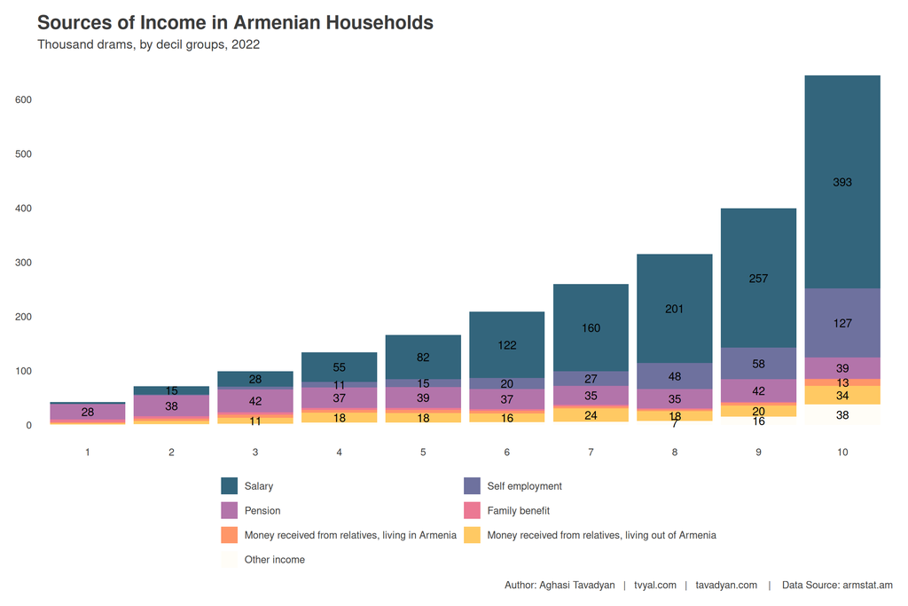

3-ից 5-րդ դեցիլային խմբերի դրամական եկամուտի ավելի քան 10 տոկոսը ստանում են բարեկամներից, որոնք գտնվում են արտասահմանում։ Սա ամենամեծ տեսակարար կշիռն է։ Այս եկամուտը ստացվում է արտագնա աշխատողներից։

Ինչքան տնային տնտեսությունը ապահով է այնքան մեծանում է ինքնազբաղվածությունից կամ բիզնեսից ստացված եկամուտի մասնաբաժինը։ Հուշագրավ է այն որ 10-րդ խմբում, որը ներկայացնում է ամենաապահով 10 տոկոսը, աշխատավարձից ստացված եկամուտի տոկոսային կշիռը ավելի ցածր է, քան 9-րդ խմբում։ Ամենաապահով խավը առանձնանում է ինքնազբաղվածների համեմատաբար մեծ տոկոսով։ Նշենք նաև որ այս խմբի եկամտների 1 տոկոսը ձևավորվում է անշարժ գույքի վաճառքից, որը գծապատկերում ներառված է “այլ եկամուտներ” սանդղակում։

**Գծապատկեր 3.** Դեցիլային խմբերի եկամտների աղբյուրները, տոկոս

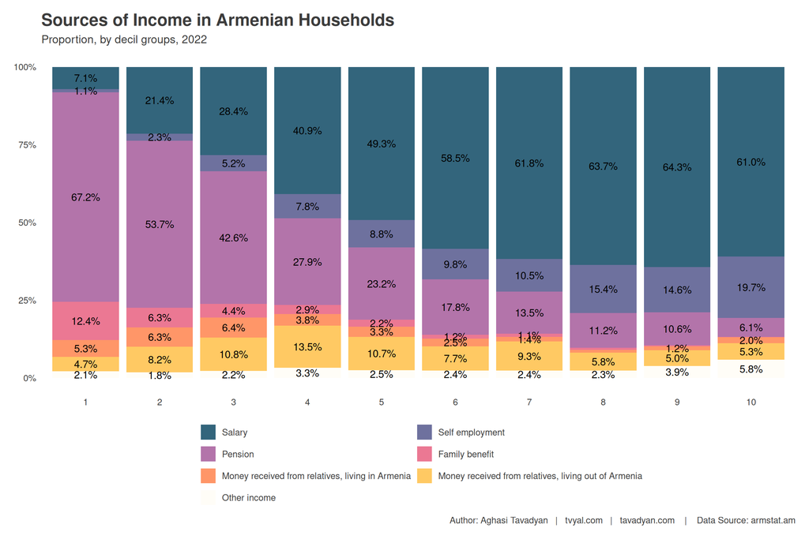

*Նշում․ Տնային տնտեսությունների եկամուտները ձևավորվում են դրամական և ոչ դրամական աղբյուրներից։ Դեցիլային խմբերը հաշվարկվել են ընդհանուր եկամտի հիման վրա։ 2-րդ և 3-րդ գծապատկերները արտացոլում են միայն դրամական եկամուտների բաշխվածությունը ըստ խմբերի։ Առաջին աղյուսակի դեցիլային խմբերի միջին եկամուտը հաշվարկվել է կշռված մեդիանով։

Այս վերլուծության տվյալները վերցված են պաշտոնական աղբյուրից, մասնավորապես՝ [տնային տնտեսությունների կենսամակարդակի (կենսապայմանների) ամբողջացված հետազոտության անվանազերծված միկրոտվյալների բազա (ըստ տնային տնտեսությունների)](https://www.armstat.am/en/?nid=205)։ Տնային տնտեսությունների կենսամակարդակի ցուցանիշները կշռվել են։ Հաշվարկները կարելի է ստուգել այցելելով [github-ի](https://github.com/tavad/tvyal_newsletter/tree/main/2024) մեր էջը, որտեղ տրված են տվյալները, հաշվարկների և գծապատկերների կոդը։

## 2. ԶԼՄ հաղորդագրություններ

Այս շաբաթ ԶԼՄ հաղարդագրություն առկա չէ։

## 3. English Summary

**Complete Family: Affluent Family**

In this study of Armenian families, the focus is on the correlation between household income, family composition, and socio-economic status. Families with a monthly income below 123 thousand drams, falling within the 1-2 decile groups, predominantly consist of elderly individuals, with over 35 percent being retirees aged 63 and above. These households are often incomplete, with only one-third having a married couple, and a lower proportion of children and working-age individuals. The analysis reveals a clear connection between lower household income, higher age of the household head, and a greater likelihood of being in a disadvantaged category. Vulnerable households are primarily characterized by elderly women without relatives, comprising about 40 percent of whom have basic education. On the other hand, the affluent class, represented by the 10th decile group, exhibits larger families with more working members, highlighting the presence of a complete family as a hallmark of economic well-being.

The second part of the analysis emphasizes the primary income sources of different decile groups. The first, second, and third decile groups, with total incomes up to 161 thousand drams, rely significantly on pensions, constituting 67 percent of the income for households up to 85 thousand AMD. The 3rd to 5th decile groups receive a substantial portion of their monetary income from relatives abroad, particularly from expatriate workers. Interestingly, wealthier households, especially in the 10th group representing the most secure 10 percent, exhibit a higher share of income from self-employment or business, with a relatively lower percentage from wages. This class is also characterized by a notable contribution from the sale of real estate in their overall income structure. Overall, the study underscores the intricate relationship between income sources, family structure, and social class in Armenian households.

## Այս վերլուծությունը առկա է նաև [մեր կայքէջում](https://www.tvyal.com/newsletter/2024/2024_01_26), այս վերլուծության կոդը և տվյալները դրված են նաև [Github-ում](https://github.com/tavad/tvyal_newsletter)։

Եթե հնարավոր է, խնդրում եմ այս նյութը ուղարկել նաև այն մարդկանց, ում այն կարծում եք կարող է հետաքրքրել:

Սպասեք հաջորդ հաղորդագրությանը հաջորդ ուրբաթ օրը:

Հարգանքներով,  
Աղասի Թավադյան  
26.01.2024  
[tvyal.com](https://www.tvyal.com/)  
[tavadyan.com](https://www.tavadyan.com/)

[Was this email forwarded to you? Subscribe here.](https://www.tvyal.com/subscribe)

[Բաժանորդագրվեք](https://www.tvyal.com/subscribe)

**Ուշադրություն. Ձեր էլ.փոստը մեյլիսթի մեջ է, որի միջոցով ես կիսվում եմ շաբաթական նյութեր, որոնք հիմնականում ներկայացնում են Հայաստանի տնտեսությանը: Նյութերը ներառում են գծապատկերներ, [տվյալների բազաներ](https://github.com/tavad/tvyal_newsletter), տեսանյութեր, հոդվածներ, [առցանց վահանակներ](https://www.tvyal.com/projects), տնտեսական գործիքներ, կանխատեսումներ և հաշվետվություններ: Եթե ցանկանում եք չեղարկել բաժանորդագրությունը, խնդրում եմ տեղեկացրեք ինձ, և ես կհեռացնեմ ձեր էլ. փոստը ցուցակից: Գրեք նաև եթե ունեք մենկնաբանություններ:**

**Important! Your email is part of the mailing list where I share weekly materials primarily focused on the Armenian economy. These materials encompass charts, [databases](https://github.com/tavad/tvyal_newsletter), videos, articles, [online dashboards](https://www.tvyal.com/projects), economic tools, forecasts, and reports. If you wish to unsubscribe, please let me know, and I will remove your email from the list. Please share your comments as well․**